# Standardization of CPUE

**1.** The longline fishery for Pacific halibut is conducted by vessels that use two different kinds of gear: fixed-hook (hooks tied directly onto the longline at a fixed hook-spacing) and snap-on (hooks snapped-onto the gear as the line goes out). The International Pacific Halibut Commission used only data from fixed-hook vessels to calculate a CPUE index. More and more vessels have used snap-on gear, and the question is whether data from snap-on vessels can be used to improve the CPUE index. Catch and CPUE data are provided for Pacific halibut from SE Alaska-Inside and Kodiak between 1976 and 1982. The data contains total catch $C$ over the two gear types, fixed-hook CPUE ($U$), and the observed ratios of snap to fixed-hook CPUE ($P_s$). **a.** Determine $U=CPUE$ of snap gear and calculate ln($U$) for all the data. **b.** Let fixed-hook gear be the reference (and standard) gear, 1980 be the reference year, and SE AK-Inside be the reference region. *The excel version of this has you construct dummy variables - that is not needed here.*

```r
lab13<-data.frame(area=c(rep("SE-AK-Inside",7),rep("Kodiak",7)),gear=rep("fixed",14),year=rep(1976:1982,2),C=c(3263,1641,2045,2696,2242,2892,2313,5540,5141,5961,6032,5304,8974,9670),U=c(42.1,37.7,46.3,77.5,75.3,139,193.1,59.4,63.3,76.3,76.1,137.2,149.6,191.4),P=c(.77,.71,.77,.76,.87,.75,.5,.68,.64,.61,.55,.43,.75,.63))
```

One way to approach this is to create another data.frame that repeats much of the information present in the lab13 data.frame then bind the two data.frames together.

```r
snap<-data.frame(area=c(rep("SE-AK-Inside",7),rep("Kodiak",7)),gear=rep("snap",14),year=rep(1976:1982,2),C=NA,U=lab13$U*lab13$P,P=NA)
(data<-rbind(lab13,snap))
```

```
##            area  gear year    C       U    P
## 1  SE-AK-Inside fixed 1976 3263  42.100 0.77
## 2  SE-AK-Inside fixed 1977 1641  37.700 0.71
## 3  SE-AK-Inside fixed 1978 2045  46.300 0.77
## 4  SE-AK-Inside fixed 1979 2696  77.500 0.76
## 5  SE-AK-Inside fixed 1980 2242  75.300 0.87
## 6  SE-AK-Inside fixed 1981 2892 139.000 0.75
## 7  SE-AK-Inside fixed 1982 2313 193.100 0.50
## 8        Kodiak fixed 1976 5540  59.400 0.68
## 9        Kodiak fixed 1977 5141  63.300 0.64
## 10       Kodiak fixed 1978 5961  76.300 0.61
## 11       Kodiak fixed 1979 6032  76.100 0.55
## 12       Kodiak fixed 1980 5304 137.200 0.43
## 13       Kodiak fixed 1981 8974 149.600 0.75
## 14       Kodiak fixed 1982 9670 191.400 0.63
## 15 SE-AK-Inside  snap 1976   NA  32.417   NA
## 16 SE-AK-Inside  snap 1977   NA  26.767   NA
## 17 SE-AK-Inside  snap 1978   NA  35.651   NA
## 18 SE-AK-Inside  snap 1979   NA  58.900   NA
## 19 SE-AK-Inside  snap 1980   NA  65.511   NA
## 20 SE-AK-Inside  snap 1981   NA 104.250   NA
## 21 SE-AK-Inside  snap 1982   NA  96.550   NA
## 22       Kodiak  snap 1976   NA  40.392   NA
## 23       Kodiak  snap 1977   NA  40.512   NA
## 24       Kodiak  snap 1978   NA  46.543   NA
## 25       Kodiak  snap 1979   NA  41.855   NA
## 26       Kodiak  snap 1980   NA  58.996   NA
## 27       Kodiak  snap 1981   NA 112.200   NA
## 28       Kodiak  snap 1982   NA 120.582   NA
```

```r
str(data)
```

```
## 'data.frame':    28 obs. of  6 variables:
##  $ area: Factor w/ 2 levels "Kodiak","SE-AK-Inside": 2 2 2 2 2 2 2 1 1 1 ...
##  $ gear: Factor w/ 2 levels "fixed","snap": 1 1 1 1 1 1 1 1 1 1 ...
##  $ year: int  1976 1977 1978 1979 1980 1981 1982 1976 1977 1978 ...
##  $ C   : num  3263 1641 2045 2696 2242 ...
##  $ U   : num  42.1 37.7 46.3 77.5 75.3 ...
##  $ P   : num  0.77 0.71 0.77 0.76 0.87 0.75 0.5 0.68 0.64 0.61 ...
```

```r
data$lnU<-log(data$U)
data$Year<-factor(data$year) #Create a factor year for the analysis
```

**c.** Apply the general linear model to the data, using ln($U$) as the dependent variable and the block of x’s as the independent variables in a multiple linear regression. Have the regression compute predicted values (by calculating residuals). From the t-statistics for the parameter estimates, which are statistically significant?  
**Note that I use “relevel” to set the reference gear, year, and location.

```r
summary(m1<-glm(lnU~relevel(gear, "fixed")+relevel(Year,"1980")+relevel(area,"SE-AK-Inside"),data=data))
```

```
##
## Call:
## glm(formula = lnU ~ relevel(gear, "fixed") + relevel(Year, "1980") +
##     relevel(area, "SE-AK-Inside"), data = data)
##
## Deviance Residuals:
##     Min       1Q   Median       3Q      Max
## -0.2811  -0.1042   0.0000   0.1182   0.2576
##
## Coefficients:
##                                     Estimate Std. Error t value Pr(>|t|)
## (Intercept)                          4.48347    0.09427  47.560  < 2e-16
## relevel(gear, "fixed")snap          -0.41268    0.06285  -6.566 2.75e-06
## relevel(Year, "1980")1976           -0.62524    0.11758  -5.318 3.93e-05
## relevel(Year, "1980")1977           -0.68407    0.11758  -5.818 1.32e-05
## relevel(Year, "1980")1978           -0.47966    0.11758  -4.080 0.000639
## relevel(Year, "1980")1979           -0.25256    0.11758  -2.148 0.044820
## relevel(Year, "1980")1981            0.45173    0.11758   3.842 0.001099
## relevel(Year, "1980")1982            0.59434    0.11758   5.055 7.03e-05
## relevel(area, "SE-AK-Inside")Kodiak  0.19705    0.06285   3.135 0.005447
##
## (Intercept)                         ***
## relevel(gear, "fixed")snap          ***
## relevel(Year, "1980")1976           ***
## relevel(Year, "1980")1977           ***
## relevel(Year, "1980")1978           ***
## relevel(Year, "1980")1979           *
## relevel(Year, "1980")1981           **
## relevel(Year, "1980")1982           ***
## relevel(area, "SE-AK-Inside")Kodiak **
## ---
## Signif. codes:  0 '***' 0.001 '**' 0.01 '*' 0.05 '.' 0.1 ' ' 1
##
## (Dispersion parameter for gaussian family taken to be 0.02764824)
##
##     Null deviance: 8.26314  on 27  degrees of freedom
## Residual deviance: 0.52532  on 19  degrees of freedom
## AIC: -11.866
##
## Number of Fisher Scoring iterations: 2
```

```r
data$pred.lmU<-fitted(m1)
data$pred.U<-exp(fitted(m1))
data$E.effort<-data$C*1000/data$U
data$pred.effort<-data$C*1000/data$pred.U
```

Plots

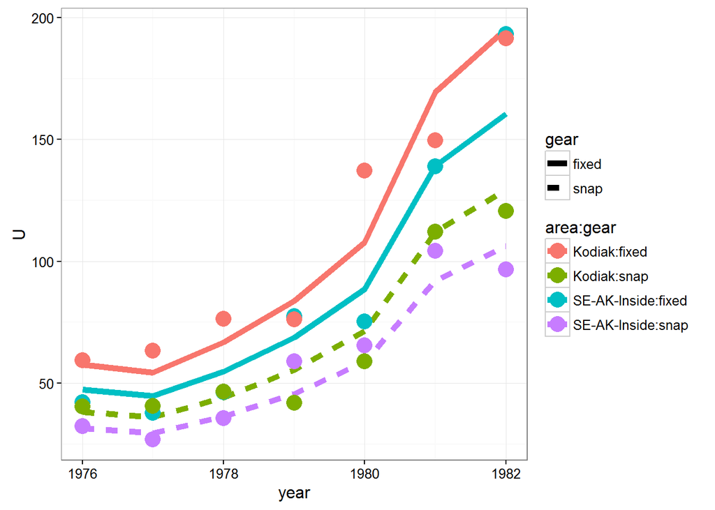

```r
ggplot(data,aes(year,U,group=area:gear,color=area:gear))+
geom_line(data=data,aes(year,pred.U,linetype=gear),size=2)+theme_bw()+geom_point(size=5)
```

How I would run this analysis using ggplot2, aka get there faster.  
a. model the data, don’t worry about re-leveling.

```r
summary(m2<-glm(lnU~gear+Year+area-1,data=data))
```

```
##
## Call:
## glm(formula = lnU ~ gear + Year + area - 1, data = data)
##
## Deviance Residuals:
##     Min       1Q   Median       3Q      Max
## -0.2811  -0.1042   0.0000   0.1182   0.2576
##
## Coefficients:
##                  Estimate Std. Error t value Pr(>|t|)
## gearfixed         4.05528    0.09427  43.017  < 2e-16 ***
## gearsnap          3.64260    0.09427  38.640  < 2e-16 ***
## Year1977         -0.05884    0.11758  -0.500  0.62254
## Year1978          0.14558    0.11758   1.238  0.23074
## Year1979          0.37268    0.11758   3.170  0.00505 **
## Year1980          0.62524    0.11758   5.318 3.93e-05 ***
## Year1981          1.07696    0.11758   9.160 2.12e-08 ***
## Year1982          1.21958    0.11758  10.373 2.91e-09 ***
## areaSE-AK-Inside -0.19705    0.06285  -3.135  0.00545 **
## ---
## Signif. codes:  0 '***' 0.001 '**' 0.01 '*' 0.05 '.' 0.1 ' ' 1
##
## (Dispersion parameter for gaussian family taken to be 0.02764824)
##
##     Null deviance: 510.08024  on 28  degrees of freedom
## Residual deviance:   0.52532  on 19  degrees of freedom
## AIC: -11.866
##
## Number of Fisher Scoring iterations: 2
```

Create a dataframe for predicting the model and plot the results

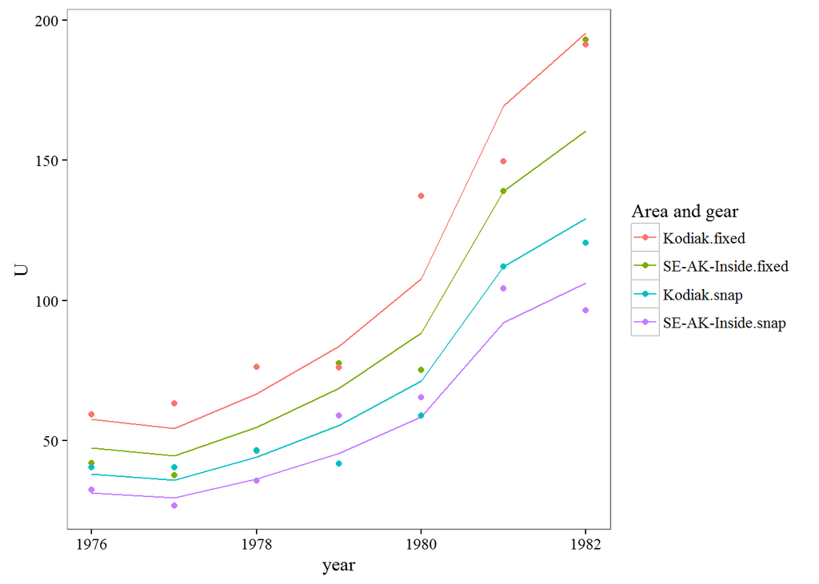

```r
newd <- expand.grid(gear=levels(data$gear), year=as.numeric(levels(data$Year)),area=levels(data$area))
newd$Year <- factor(newd$year)
newd$pred <- predict(m2, newd, type='response')
newd$U <- exp(newd$pred)
ggplot(newd, aes(year, U, color=interaction(area,gear)))+geom_line()+#this is the modeled data layer
geom_point(data=data, aes(year, U))+ # this is the observed data
scale_color_discrete(name="Area and gear")
```

This is a lab exercise from Dr. Terry Quinn at the University of Alaska Fairbanks and has been coded in R by: Ben Williams bcwilliams2@alaska.edu ben.williams@alaska.gov